# Project 4, APS1070 Winter 2023

#### **Linear Regression - 15 points**

**Deadline: April 3rd, 23:00**

**Academic Integrity**

This project is individual - it is to be completed on your own. If you have questions, please post your query in the APS1070 Piazza Q&A forums (the answer might be useful to others!).

Do not share your code with others, or post your work online. Do not submit code that you have not written yourself. Students suspected of plagiarism on a project, midterm or exam will be referred to the department for formal discipline for breaches of the Student Code of Conduct.

Please fill out the following:

- Your **name**: **Abhishek Patel**
- Your **student number**: **1009311031**

### How to submit **(HTML [This notebook] + IPYNB + GitHub [Part 6])**

1. Download your notebook: `File -> Download .ipynb`
2. Click on the Files icon on the far left menu of Colab
3. Select & upload your `.ipynb` file you just downloaded, and then obtain its path (right click) (you might need to hit the Refresh button before your file shows up)
1. execute the following in a Colab cell:

   ```
   %%shell
   jupyter nbconvert --to html /PATH/TO/YOUR/NOTEBOOKFILE.ipynb
   ```

2. An HTML version of your notebook will appear in the files, so you can download it.
3. Submit **both** `HTML` and `IPYNB` files for this notebook on Quercus for grading.
4. Make sure you compeleted the last part on **GitHub** and added your link to the last cell here. The teaching team will view and grade your part 7 on GitHub.

Ref: https://stackoverflow.com/a/64487858

## Part 1 - Getting Started [2 marks]

In this project, we are going to design a mathematical model that predicts the critical temperature of a superconductor, as described in the paper below:

*Hamidieh, Kam, A data-driven statistical model for predicting the critical temperature of a superconductor, Computational Materials Science, Volume 154, November 2018, Pages 346-354*

**The following dataset contains 21263 instances, where each instance is a set of 81 features describing the superconductor's status. Our goal is to use these features to predict the `critical_temp` column, which is a setting that the design should take into account. We will make our predictions by implementing linear regression.**

```python
import pandas as pd
import numpy as np
import matplotlib.pyplot as plt
import seaborn as sns
import scipy as scipy
import time
from sklearn.model_selection import train_test_split
from sklearn.metrics import mean_squared_error
from IPython import display as show

sns.set_theme(context='notebook', style='darkgrid', palette='brg', font='sans-serif', font_scale=1.5, color_codes=True)
```

```python
df = pd.read_csv("https://raw.githubusercontent.com/APS1070-W23/datasets/main/superconduct.csv" , skipinitialspace=True)
```

Here are the steps to complete this portion:

1. Print the dataframe.
2. Prepare your dataset as follows: **[1.5]**
- Using `train_test_split` from Sklearn, split the dataset into training and validation sets ($80\%$ training, $20\%$ validation). When splitting, set `random_state=1`. **[0.5]**
- Standardize the data **manually** according to the same method as `StandardScaler` from sklearn, but you may not directly use `StandardScaler'. **[0.5]**
- Insert a first column of all $1$s in both the training and validation data sets. **[0.5]**
1. Explain why we should not insert the column of $1$s prior to standardization. **[0.5]**

```python
# For the 2nd part - Manual Standardization

def StandardScaler(X):
    X_mean = X.mean(axis = 0) # Mean
    X_std = X.std(axis = 0) # Standard Deviation

    # Standardizing
    X_standard = (X - X_mean) / X_std

    return X_standard
```

```python
# Split the data
X = df.iloc[:,:-1]
y = df.iloc[:,-1]

# Splitting the train:val set ---> 80:20
X_train, X_val, y_train, y_val = train_test_split(X, y, test_size = 0.2, random_state = 1)

print('Train set:', X_train.shape, y_train.shape)
print('Train set % = ', (X_train.shape[0]/(X_train.shape[0] + X_val.shape[0]))*100)

print('\nValidation set:', X_val.shape, y_val.shape)
print('Validation set % = ', (X_val.shape[0]/(X_train.shape[0] + X_val.shape[0]))*100)
```

```
Train set: (17010, 81) (17010,)
Train set % =  79.99811879791187

Validation set: (4253, 81) (4253,)
Validation set % =  20.001881202088136
```

```python
# Standardizing the Data
# Training Set
X_train = StandardScaler(X_train)
y_train = y_train.values

# Validation Set
X_val = StandardScaler(X_val)
y_val = y_val.values
```

```python
# Inserting the 1s column to the dataset
X_train = np.c_[np.ones(X_train.shape[0]), X_train]
X_val = np.c_[np.ones(X_val.shape[0]), X_val]
```

**Explain why we should not insert the column of 1s prior to standardization. [0.5]**

Inserting `column` of 1s is also known as `Bias Term`

If we insert `Bias Term` before standardization, then the `mean of Bias Term will be 1` and the `standard deviation will be 0.` This means that the `standardization procedure` will `not have any effect` on this column, leaving it unchanged. As a result, the bias term will not be learned properly during the training process.

Therefore, it is better to standardize the data first and then insert the column of 1s. This will ensure that the bias term is also properly scaled and centered along with the other features, allowing for accurate and effective learning during the gradient descent process.

## Part 2 - Linear Regression Using Direct Solution [1 marks]

Implement the direct solution of the linear regression problem on the training set. **[0.5]**

**Note: You should use scipy.linalg.inv to perform the inversion, as numpy.linalg.inv may caue an error.**

Report the root-mean-square error (RMSE) for both the training and validation sets. **[0.5]**

You may use `mean_squared_error` from Sklearn for computing the RMSE.

```python
# Direct Solution for Linear Solution

# Analytical Solution
W = np.dot(scipy.linalg.inv(np.dot(X_train.T, X_train)), np.dot(X_train.T, y_train))

# Predictions for Train and Validation Sets
y_train_pred = np.dot(X_train, W)
y_val_pred = np.dot(X_val, W)
```

```python
# Root Mean Square Error (RMSE) Function
def rmse(yPred, y):
    return np.sqrt(mean_squared_error(yPred, y))

ds_train_RMSE = rmse(y_train_pred, y_train)
ds_val_RMSE = rmse(y_val_pred, y_val)

# RMSE for Training Set and Validation Set
print('Training Set RMSE:', ds_train_RMSE)
print('Validation Set RMSE:', ds_val_RMSE)
```

```
Training Set RMSE: 17.495025140326373
Validation Set RMSE: 17.848835825934565
```

## Part 3 - Full Batch Gradient Descent [3 marks]

We will now implement a "full batch" gradient descent algorithm and record the training time for our model. Recall that the full batch gradient descent is $$w_t = w_{t-1} - \alpha~g_t$$ where $\alpha$ is the learning rate and $g_t$ is your gradient, computed on the entire data.

Here are the steps for this part:

- Implement gradient descent for linear regression using a fixed learning rate of $\alpha= 0.01$, and iterate until your model's **validation** RMSE converges.

  We consider the gradient descent as having converged when RMSE on the validation set using gradient descent satisfies:

  $$ RMSE_\text{GD} \leq 1.001 \times RMSE_\text{Direct Solution}$$

  where $RMSE_\text{Direct Solution}$ is the RMSE on the validation set using the direct solution that you calculated in the previous part.

  We refer to the quantity $RMSE_\text{Direct Solution}\times 1.001$ as the convergence threshold (CT).
- Record the training time (from the first iteration until convergence) using the `time.time()` function. Be sure to compute the gradients yourself! Take a look at the code provided in the tutorial. **[1]**
- Plot the training RMSE and the validation RMSE vs. epoch on the same figure. **[1]**
- Comment on overfitting/underfitting by observing the training and validation RMSE **[1]**

**Hint**: Initialize your weights with small random numbers (<$0.001$)

```
Total Training Time: 99.839 (s)
Training RMSE = 17.578
Validation RMSE = 17.867
```

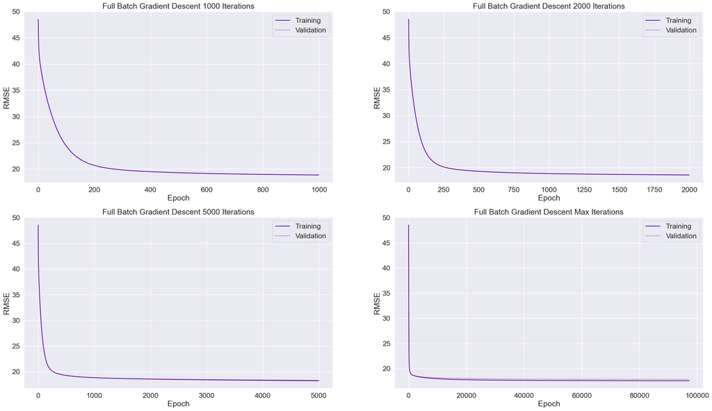

```python
def full_batch_gradient_descent(X_train, y_train, X_val, y_val, learning_rate = 0.01):

    start_time = time.time() # Records Current Time

    # Initialize weight vector W
    W = np.random.random(X_train.shape[1]) / 1000

    # Set learning rate alpha
    alpha = learning_rate

    # Calculate Convergence Threshold
    CT = ds_val_RMSE

    # Initialize Training RMSE and Validation RMSE
    train_RMSE = []
    val_RMSE = []

    # Initial Validation Value
    y_val_pred = np.dot(X_val, W.T)
    val_RMSE.append(np.sqrt(mean_squared_error(y_val_pred, y_val)))

    # For remaining Epochs, loop untill Convergence
    while val_RMSE[-1] > 1.001 * CT:

        # Calculate Training RMSE & Predicted values on the Training Set using the Updated Weights
        y_train_pred = np.dot(X_train, W.T)
        train_RMSE.append(np.sqrt(mean_squared_error(y_train_pred, y_train)))

        # Calculate Validation RMSE & Predicted values on the Validation Set using the Updated Weights
        y_val_pred = np.dot(X_val, W.T)
        val_RMSE.append(np.sqrt(mean_squared_error(y_val_pred, y_val)))

        # Calculate Gradient of the Mean Squared Error loss Function w.r.t W using the entire Training Set
        gradient = (1 / len(y_train_pred) * np.dot(X_train.T, (y_train_pred - y_train)))

        # Update Weights
        W = W - alpha * gradient

        # if val_RMSE[-1] <= 1.001 * CT:
        #   break

    # Remove Initial Value
    val_RMSE.pop(0)

    # Plot
    fig, axes = plt.subplots(2, 2, figsize = (28, 16), dpi = 100)
    # Top-Left
    sns.lineplot(data = train_RMSE[:1000], label = 'Training', ax = axes[0, 0])
    sns.lineplot(data = val_RMSE[:1000], label = 'Validation', ax = axes[0, 0], ls = ':')
    axes[0, 0].set_xlabel("Epoch")
    axes[0, 0].set_ylabel("RMSE")
    axes[0, 0].set_title('Full Batch Gradient Descent 1000 Iterations')
    axes[0, 0].legend()
    # Top-Right
    sns.lineplot(data = train_RMSE[:2000], label = 'Training', ax = axes[0, 1])
    sns.lineplot(data = val_RMSE[:2000], label = 'Validation', ax = axes[0, 1], ls = ':')
    axes[0, 1].set_xlabel("Epoch")
    axes[0, 1].set_ylabel("RMSE")
    axes[0, 1].set_title('Full Batch Gradient Descent 2000 Iterations')
    axes[0, 1].legend()
    # Bottom-Left
    sns.lineplot(data = train_RMSE[:5000], label = 'Training', ax = axes[1, 0])
    sns.lineplot(data = val_RMSE[:5000], label = 'Validation', ax = axes[1, 0], ls = ':')
    axes[1, 0].set_xlabel("Epoch")
    axes[1, 0].set_ylabel("RMSE")
    axes[1, 0].set_title('Full Batch Gradient Descent 5000 Iterations')
    axes[1, 0].legend()
    # Bottom-Right
    sns.lineplot(data = train_RMSE, label = 'Training', ax = axes[1, 1])
    sns.lineplot(data = val_RMSE, label = 'Validation', ax = axes[1, 1], ls = ':')
    axes[1, 1].set_xlabel("Epoch")
    axes[1, 1].set_ylabel("RMSE")
    axes[1, 1].set_title('Full Batch Gradient Descent Max Iterations')
    axes[1, 1].legend()

    print("Total Training Time: %.3f (s)" % (time.time() - start_time))
    print("Training RMSE = %.3f" % train_RMSE[-1])
    print("Validation RMSE = %.3f" % val_RMSE[-1])

# Function Calling
full_batch_gradient_descent(X_train, y_train, X_val, y_val)
```

**Comment on overfitting/underfitting by observing the training and validation RMSE [1]**

Based on the `4 graphs`, there are no signs of `Overfitting or Underfitting` of the Model, as the `Validation and Train RMSE` are following the same trend, for `1000, 2000 and 5000 iterations`. If we let the model run for `all possible iterations (100000 iterations)`, then it can be seen that the `validation RMSE is only slightly above train RMSE but it can not be termed as Overfitting.`

Thus, up until approximately `3000 iterations (Epochs),` it can be said that the `model fits well,` and after slightly less well.

## Part 4 - Mini-batch and Stochastic Gradient Descent [4 marks]

Write a function that performs mini-batch gradient descent until the convergence threshold (CT) is reached. **[1]**

The inputs of that function are:

- Input data (training/validation), Batch size, Learning Rate, Convergence Threshold (CT)

Your function will return the following arrays:

- The final weights after training.
- The training RMSE at each epoch.
- The validation RMSE at each epoch.
- An array that has the elapsed time from the start of the training process to the end of each epoch (e.g., if each epoch takes exactly 2 seconds, the array would look like: [2 4 6 8 ...]).

Notes:

- For certain batch sizes, GD might not converge to a solution. For that reason, you need to check the RMSE of the validation/training set at each epoch, and if it's getting larger and larger, you should stop the training for that case (the design is up to you!).
- CT will help you to know when your model is converged.
- **Important: after each epoch, you need to shuffle the entire training set.** This ensures that new mini-batches are selected for every epoch. Hint: use `np.random.permutation`.

Let's now use the function to investigate the effect of batch size on convergence. When the batch size is 1, we call that stochastic gradient descent. When the batch size equals the # of training data, it is full-batch (i.e., all data points are used at every iteration). Anywhere in between is mini-batch (we use some of the data).

- Sweep different values for the mini-batch size (at least 5 values that **converge**), each time using a learning rate of $\alpha= 0.01$. **Hint: Try batch sizes that are powers of two (e.g., 2,4,8,16,32,64,128...).** These batch sizes fit better on the hardware and may achieve higher performance. **[0.5]**

Provide the following $3$ plots:

1. Plot training and validation RMSE vs. **epoch** for all the **converging** batch sizes (some batch sizes might not converge) in a figure. The X-axis is Epoch # and the Y-axis is RMSE. **[0.5]**
2. Plot training and validation RMSE vs. **time** for all the **converging** batch sizes in a figure. The X-axis is Time, and the Y-axis is RMSE. **[0.5]**
3. Plot Total training time (y-axis) vs. Batch size (x-axis). **[0.5]**

Describe your findings, including the main takeaways from each of your plots. **[1]**

```python
def mini_batch_gradient_descent(X_train, y_train, X_val, y_val, bs, learning_rate = 0.01, threshold = rmse(y_val_pred, y_val)):

    # Initialize weight vector W
    W = np.random.random(X_train.shape[1]) / 1000

    # Set learning rate alpha
    alpha = learning_rate

    # Initialize Training RMSE, Validation RMSE & Epoch Times
    val_RMSE = []
    train_RMSE = []
    epoch_time = []

    # Initialize Batch Size & Convergance Flag (RED FLAG)
    batch_size = 2 ** bs
    flag_converge = True
    c_diverge = 8

    # Initial Validation Value
    y_val_pred = np.dot(X_val, W.T)
    val_RMSE.append(rmse(y_val_pred, y_val))

    start_time = time.time() # Records Current Time

    # For remaining Epochs, Loop untill Convergence
    while val_RMSE[-1] > 1.001 * threshold and flag_converge:

        # Update Validation with New Updated W
        y_val_pred = np.dot(X_val, W.T)
        rmse_val = rmse(y_val_pred, y_val)
        val_RMSE.append(rmse_val)

        # Check Divergance after Validation Update
        if len(val_RMSE) > c_diverge:
            rmse_check = val_RMSE[-c_diverge:]
            if all([rmse_check[-r] > rmse_check[-(r + 1)] for r in range(1, len(rmse_check))]):
                print('Divergance at Batch Size = %d' %(2 ** bs))
                flag_converge = False

        # Update Training with New Updated W
        y_train_pred = np.dot(X_train, W.T)
        rmse_train = rmse(y_train_pred, y_train)
        train_RMSE.append(rmse_train)

        # Update Batch Gradient after each Iteration
        for b in range(0, X_train.shape[0], batch_size):
            X_batch = X_train[b:b + batch_size]
            y_batch = y_train[b:b + batch_size]
            y_pred_batch = np.dot(X_batch, W.T)
            gradient = (1 / len(y_pred_batch) * np.dot(X_batch.T, (y_pred_batch - y_batch)))
            W = W - alpha * gradient

        # Add each Epoch Time
        epoch_time.append(time.time() - start_time)

        # Shuffling Train Set after each Batch Size
        rand = list(np.random.permutation(X_train.shape[0]))
        X_train = X_train[rand]
        y_train = y_train[rand]

    # Remove Initial Value
    val_RMSE.pop(0)

    return W, train_RMSE, val_RMSE, epoch_time, flag_converge
```

```
Divergance at Batch Size = 2
Divergance at Batch Size = 4
```

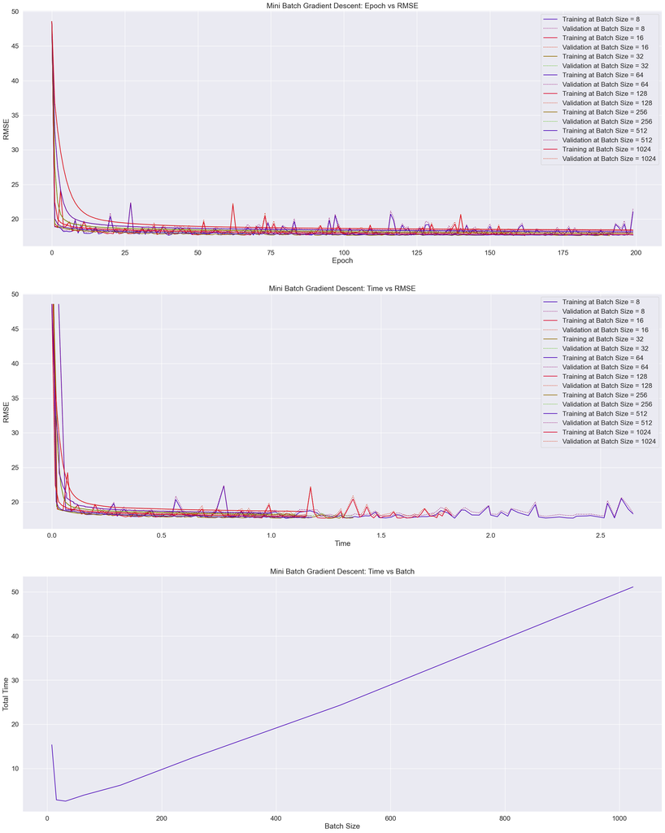

```
Fastest Converge Batch Size: 32
```

```python
# Function Calling and Plotting Graphs
plt.figure(figsize = (28,36), dpi = 100)

# Initialize Epoch Time List
process_time = []

# Convergence Batch & Time Lists
converge_batch = []
converge_time = []

np.random.seed(21)

for i in range(1, 11):

    W, train_RMSE, val_RMSE, process_time, flag = mini_batch_gradient_descent(X_train, y_train, X_val, y_val, i)
    if flag:

        # Plot RMSE v/s Epochs
        plt.subplot(3,1,1)
        plt.plot(train_RMSE[:200], label = 'Training at Batch Size = %d' %(2 ** i))
        plt.plot(val_RMSE[:200], ls = ':', label = 'Validation at Batch Size = %d' %(2 ** i))
        plt.xlabel("Epoch")
        plt.ylabel("RMSE")
        plt.title('Mini Batch Gradient Descent: Epoch vs RMSE')
        plt.legend()

        # Plot RMSE vs Time
        plt.subplot(3,1,2)
        plt.plot(process_time[:100], train_RMSE[:100], label = 'Training at Batch Size = %d' %(2 ** i))
        plt.plot(process_time[:100], val_RMSE[:100], ls = ':', label = 'Validation at Batch Size = %d' %(2 ** i))
        plt.xlabel("Time")
        plt.ylabel("RMSE")
        plt.title('Mini Batch Gradient Descent: Time vs RMSE')
        plt.legend()

        # Append the Last Times for each Batch
        converge_time.append(process_time[-1])
        converge_batch.append(2 ** i)

plt.subplot(3,1,3)
plt.plot(converge_batch, converge_time)
plt.xlabel("Batch Size")
plt.ylabel("Total Time")
plt.title('Mini Batch Gradient Descent: Time vs Batch')
plt.show()

# Calculate Fastest for Part 5
fastest_batch_size = converge_batch[converge_time.index(min(converge_time))]
print('Fastest Converge Batch Size: %d' %fastest_batch_size)
```

**Describe your findings, including the main takeaways from each of your plots. [1]**

`Graph 1: RMSE v/s Epoch:`

- `As the batch size increases, the RMSE drops more and more slowly, thus smoothening the graph.`
- With Smaller batch sizes, it can be seen that there a lot of ups and downs with the graphs, especially for batch sizes 8 - 32. Which is why I have added 'c_diverge = 8', to prevent them from diverging and ultimatly not giving a result at all.

`Graph 2: RMSE v/s Time:`

- The fastest batch to converge was `Batch Size = 32.`
- Another batch was close to it, but not quite the fastest.
- After that, the other batches took the most time, even though Batch size 16 took more time even though it was a smaller batch, but in general, `As the Batch Size increased, the more time Gradient Descent took to converge.`

## Part 5 - Gradient Descent Learning Rate [3 marks]

Use the function that you designed in Part 4 to investigate the effect of learning rate on convergence.

1. Pick 3 batch sizes that do not converge with a learning rate of $\alpha= 0.01$ (last part) and try to find a learning rate that results in convergence for each batch size. Report your findings in a table. Mention batch size, learning rate, and training and validation RMSE. **[1]**
2. Select the best batch size based on Part 4's fastest convergence time and sweep the learning rate (at least 10 values, all should converge) while applying Mini-batch GD.
   - Plot the training and validation RMSE vs. **epoch** (x-axis) for all the learning rates that you tried in a figure. **[0.5]**
   - Plot the training and validation RMSE vs. **time** (x-axis) for all the learning rates that you tried in a figure. **[0.5]**
   - Describe your findings, including the main takeaways from each of your plots. **[1]**

```python
# Part 1
np.random.seed(21)
results = []
print('"For" loop Processing: ', end = '', flush = True)

for lr in np.arange(0.001, 0, -0.0002):
    for i in range(1, 4):
        print('..', end = '', flush = True)

        W, train_RMSE, val_RMSE, process_time, flag = mini_batch_gradient_descent(X_train, y_train, X_val, y_val, i, learning_rate = lr)
        if flag:
            # Converge Results
            results.append([lr, 2 ** i, process_time[-1], train_RMSE[-1], val_RMSE[-1]])

# Create Final Dataframe
results = pd.DataFrame(results, columns = ['Learning Rate', 'Batch Size', 'Time', 'Train RMSE', 'Validate RMSE'])
results.set_index(['Learning Rate', 'Batch Size'], drop = True, inplace = True)
show.display(results)
```

```
"For" loop Processing: ..............................
```

| Learning Rate | Batch Size | Time | Train RMSE | Validate RMSE |
| --- | --- | --- | --- | --- |
| 0.0010 | 2 | 10.170944 | 17.638657 | 17.864306 |
|  | 4 | 10.109322 | 17.594584 | 17.855605 |
|  | 8 | 11.522096 | 17.600194 | 17.864436 |
| 0.0008 | 2 | 15.217101 | 17.604669 | 17.842143 |
|  | 4 | 12.062015 | 17.630955 | 17.862065 |
|  | 8 | 13.315483 | 17.611869 | 17.858400 |
| 0.0006 | 2 | 12.295379 | 17.627394 | 17.861364 |
|  | 4 | 14.809905 | 17.614183 | 17.861994 |
|  | 8 | 16.146315 | 17.602478 | 17.864498 |
| 0.0004 | 2 | 16.421919 | 17.604914 | 17.865831 |
|  | 4 | 24.477634 | 17.593562 | 17.863571 |
|  | 8 | 25.517814 | 17.596218 | 17.863866 |
| 0.0002 | 2 | 38.286963 | 17.599437 | 17.866108 |
|  | 4 | 43.827206 | 17.592489 | 17.861900 |
|  | 8 | 54.197111 | 17.591956 | 17.864893 |

```
"For" loop Processing: ......................
Fastest Converging Learning Rate: 0.0020
```

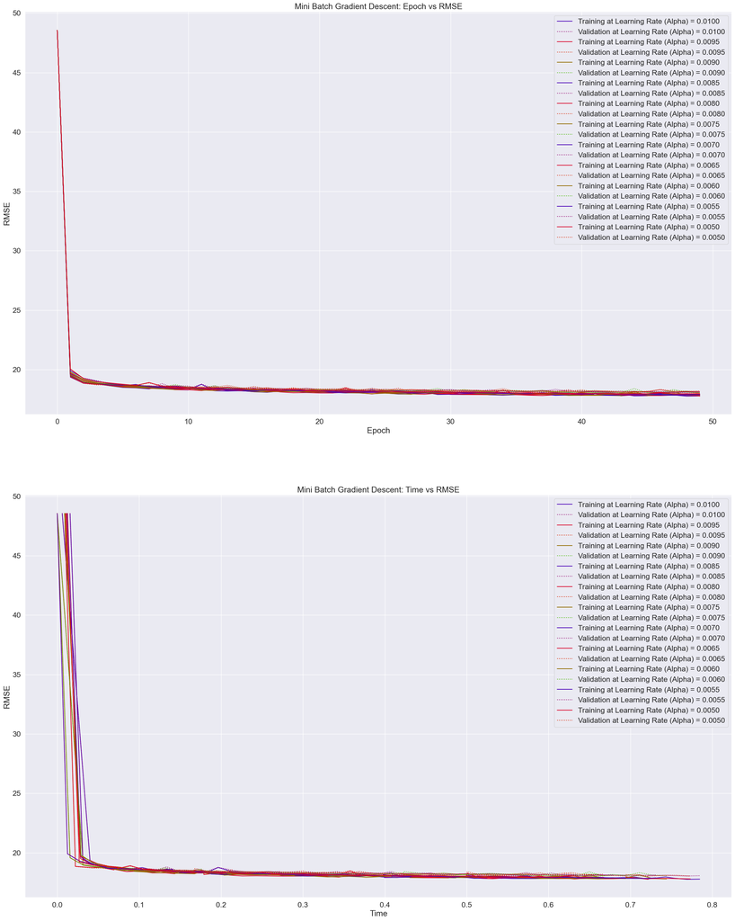

| Learning Rate | Time | Train RMSE | Validate RMSE |
| --- | --- | --- | --- |
| 0.0100 | 3.449905 | 17.649803 | 17.856300 |
| 0.0095 | 2.763570 | 17.607254 | 17.854356 |
| 0.0090 | 3.172368 | 17.618491 | 17.865670 |
| 0.0085 | 2.268218 | 17.631147 | 17.863840 |
| 0.0080 | 3.604925 | 17.610676 | 17.866638 |
| 0.0075 | 3.280295 | 17.595616 | 17.855539 |
| 0.0070 | 3.294018 | 17.611755 | 17.860245 |
| 0.0065 | 3.294426 | 17.613752 | 17.865397 |
| 0.0060 | 3.606885 | 17.598967 | 17.865087 |
| 0.0055 | 4.769591 | 17.617062 | 17.857035 |
| 0.0050 | 4.827385 | 17.593212 | 17.856960 |

```python
# Part 2
np.random.seed(21)
best_batch_time = []
results = []

plt.figure(figsize = (28,36), dpi = 100)

f_size = int(np.log2(fastest_batch_size))

print('"For" loop Processing: ', end = '', flush = True)

for lr in np.arange(0.01, 0.0045, -0.0005):

    print('..', end = '', flush = True)
    W, train_RMSE, val_RMSE, process_time, flag = mini_batch_gradient_descent(X_train, y_train, X_val, y_val, f_size, lr)

    if flag:
        # Converge Results
        results.append([lr, process_time[-1], train_RMSE[-1], val_RMSE[-1]])

        # Plot RMSE v/s Epochs
        plt.subplot(2,1,1)
        plt.plot(train_RMSE[:50], label = 'Training at Learning Rate (Alpha) = %.4f' % lr)
        plt.plot(val_RMSE[:50], ls = ':', label = 'Validation at Learning Rate (Alpha) = %.4f' % lr)
        plt.xlabel("Epoch")
        plt.ylabel("RMSE")
        plt.title('Mini Batch Gradient Descent: Epoch vs RMSE')
        plt.legend()

        # Plot RMSE vs Time
        plt.subplot(2,1,2)
        plt.plot(process_time[:50], train_RMSE[:50], label = 'Training at Learning Rate (Alpha) = %.4f' % lr)
        plt.plot(process_time[:50], val_RMSE[:50], ls = ':', label = 'Validation at Learning Rate (Alpha) = %.4f' % lr)
        plt.xlabel("Time")
        plt.ylabel("RMSE")
        plt.title('Mini Batch Gradient Descent: Time vs RMSE')
        plt.legend()

    best_batch_time.append(process_time)

# Find Fastest Converging Learning Rate
lr_ls = list(np.arange(0.011, 0.000, -0.001))
fastest_lr = lr_ls[best_batch_time.index(min(best_batch_time))]
print('\nFastest Converging Learning Rate: %.4f' %fastest_lr)
plt.show()

# Create Final Dataframe
results = pd.DataFrame(results, columns = ['Learning Rate', 'Time', 'Train RMSE', 'Validate RMSE'])
results.set_index(['Learning Rate'], drop = True, inplace = True)
show.display(results)
```

**Describe your findings, including the main takeaways from each of your plots. [1]**

`Graph 1: RMSE v/s Epoch:`

`Graph 2: RMSE v/s Time:`

- As for Graph 2, it looks similar to 1, because we choose a small batch that converges the quickest (Batch size = 32), there are some minor fluctuations that are still observed but they smooth out with time. The lower alphas values have close to null fluctuations and almost smooth graph.

## Part 6 - Getting started with Github [3 marks]

This final part of the project assignment is to be completed independently from Parts 1 - 5. In this part you will be completing some additional coding tasks using a different dataset and submitting your results on Github. To access this part of the assignment and upload your answers, you will need to use Github. Please complete the following step-by-step instructions:

1. Create a Github account and install git for Windows or Mac:
   - https://git-scm.com/download/win
   - https://git-scm.com/download/mac
2. Open this link: https://classroom.github.com/a/ODb_vtN2 to create your assignment repository in GitHub. You should get a link similar to:

   ```
   https://github.com/APS-1070-W23/project-4-*********
   ```

   This your private repository to get this part questions and upload your answers. **Copy this link to the text box below to be graded for this part.**
1. Open `Git Bash`, the app you downloaded in step `0`, and set your Email and username by:

   ```
   git config --global user.email “<your-GitHub-email>”
   git config --global user.name “<your-GitHub-username>”
   ```

2. Create a folder for the course on your computer and `cd` to that. `cd` means `Change Directory`. For example, on a Windows machine, where I have a folder on "C:\aps1070":

   ```
   cd c:aps1070
   ```

3. Get your assignment by the link you got in step 1:

   ```
   git clone https://github.com/APS-1070-W23/project-4-*********
   ```

4. A new folder should be created in your directory similar to:

   ```
   C:\aps1070\project-4-********
   ```

   This folder has an `ipynb` notebook which you need to manually upload to colab and answer its questions.
5. After you finished working on this notebook, download the notebook from colab and move it to the directory in step 5.
6. Replace the old notebook with the new one that has your answers. Make sure your completed notebook has the same name as the original notebook you downloaded.
7. To submit your work, follow:

   ```
   cd <your assignment folder>
   git add W23_Project_4_git.ipynb
   git commit -m “Final Submission”
   git push
   ```

   If you have any problem with pushing your work on GitHub you can try one of following commands:

   ```
   git push --force
   or
   git push origin HEAD:main
   ```

8. Make sure your submission is ready for grading. Open the private repository link in your browser and make sure you can see your final submission with your latest changes there. **Only you and the teaching team can open that link.**

   **Private Repository Link:** https://github.com/APS1070-W23/project-4-Aksharbrahm